# Data Visualization Assignment (psych package only)

## 0.1 Getting Started

This assignment uses datasets from **`psych`**. For each problem: - Briefly **describe your wrangling** (1–2 sentences). - Complete the `# TODO` sections. - Use tidy verbs (`filter`, `mutate`, `select`, `summarise`, `pivot_*`). - Choose **appropriate plots** (when asked) that match variable types and questions.

### 0.1.1 Packages

```r
if (!require(psych)) install.packages("psych")
if (!require(tidyverse)) install.packages("tidyverse")
if (!require(corrplot)) install.packages("corrplot")

library(psych)
library(tidyverse)
library(corrplot)
```

## 0.2 1) Big Five: Urban Legends of Extraversion?

**Data:** `psych::bfi`  
**Goal:** Compute **mean Extraversion** (E1–E5) per participant. Create a **distribution plot** (your choice: histogram, density, or violin+points). Briefly justify your choice.

```r
bfi1 <- bfi %>%
  mutate(Extraversion = rowMeans(select(., E1:E5), na.rm = TRUE)) %>%
  filter(!is.na(Extraversion))

# TODO: choose and create a distribution plot for Extraversion
# e.g., geom_histogram() or geom_density() or violin by gender
```

## 0.3 2) BFI: Gender Differences in Neuroticism

**Goal:** Compute **mean Neuroticism** (N1–N5) per participant. Compare **by gender** with a **grouped visualization** (box+ jitter or violin + points). Add sample sizes in the subtitle.

```r
bfi2 <- bfi %>%
  mutate(
    Neuroticism = rowMeans(select(., N1:N5), na.rm = TRUE),
    gender = factor(gender, levels = c(1,2), labels = c("Male","Female"))
  ) %>%
  filter(!is.na(Neuroticism), !is.na(gender))

# TODO: grouped plot comparing Neuroticism by gender
# + subtitle showing n per group
```

## 0.4 3) BFI: Trait Tradeoffs (E vs N)

**Goal:** Compute **Extraversion** and **Neuroticism** and visualize their **bivariate relationship**.  
Pick one: **scatter + smooth**, **2D density (filled)**, or **hexbin**. Briefly interpret the pattern.

```r
bfi3 <- bfi %>%
  mutate(
    E = rowMeans(select(., E1:E5), na.rm = TRUE),
    N = rowMeans(select(., N1:N5), na.rm = TRUE)
  ) %>%
  filter(!is.na(E), !is.na(N))

# TODO: pick a bivariate plot and implement
```

## 0.5 4) BFI: Education & Conscientiousness

**Goal:** Compute **Conscientiousness** (C1–C5) and compare across **education**.  
Tidy `education` as an ordered factor. Create a plot that shows **central tendency + variability** (e.g., box with jitter or mean ± CI).

```r
bfi4 <- bfi %>%
  mutate(
    C = rowMeans(select(., C1:C5), na.rm = TRUE),
    education = factor(education, levels = sort(unique(education)), ordered = TRUE)
  ) %>%
  filter(!is.na(C), !is.na(education))

# TODO: visualization of C across education levels
```

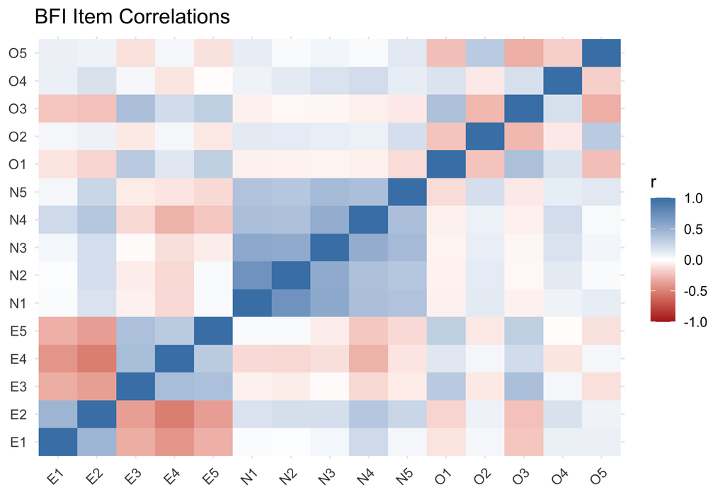

```r
bfi_items <- bfi %>%
  select(E1:O5) %>%
  na.omit()

bfi_cor <- cor(bfi_items)

# Option A: ggplot heatmap
cor_long <- as.data.frame(as.table(bfi_cor))
names(cor_long) <- c("var1","var2","r")

ggplot(cor_long, aes(var1, var2, fill = r)) +
  geom_tile() +
  scale_fill_gradient2(limits = c(-1,1), low = "firebrick", mid = "white", high = "steelblue") +
  labs(title = "BFI Item Correlations", x = NULL, y = NULL, fill = "r") +
  theme_minimal(base_size = 12) +
  theme(axis.text.x = element_text(angle = 45, hjust = 1))
```

```r
# Option B: corrplot (uncomment if you prefer)
# corrplot(bfi_cor, method="color", order="hclust", addrect=5,
#          col=colorRampPalette(c("darkred","white","navy"))(200),
#          tl.col="black", tl.cex=.6)
```

## 0.7 6) SAT & ACT: Relationships

**Data:** `psych::sat.act` (columns typically `SATV`, `SATQ`, `ACT`)  
**Goal:** Tidy column names, then visualize relationships:  
- **SATV vs SATQ** with **ACT as color or size**.  
- Add a smooth trend. Comment on any nonlinearity.

```r
data(sat.act)

sat <- sat.act %>%
  rename(SATV = SATV, SATQ = SATQ, ACT = ACT) %>%
  filter(!is.na(SATV), !is.na(SATQ), !is.na(ACT))

# TODO: scatter (SATV vs SATQ) with ACT mapped (color or size) + smooth
```

## 0.8 7) SAT & ACT: Grouped Summaries

**Goal:** Create a **binned summary** of SATV (e.g., cut into quantiles) and compute **mean ACT** per bin. Plot as a **column chart** with **95% CIs**.

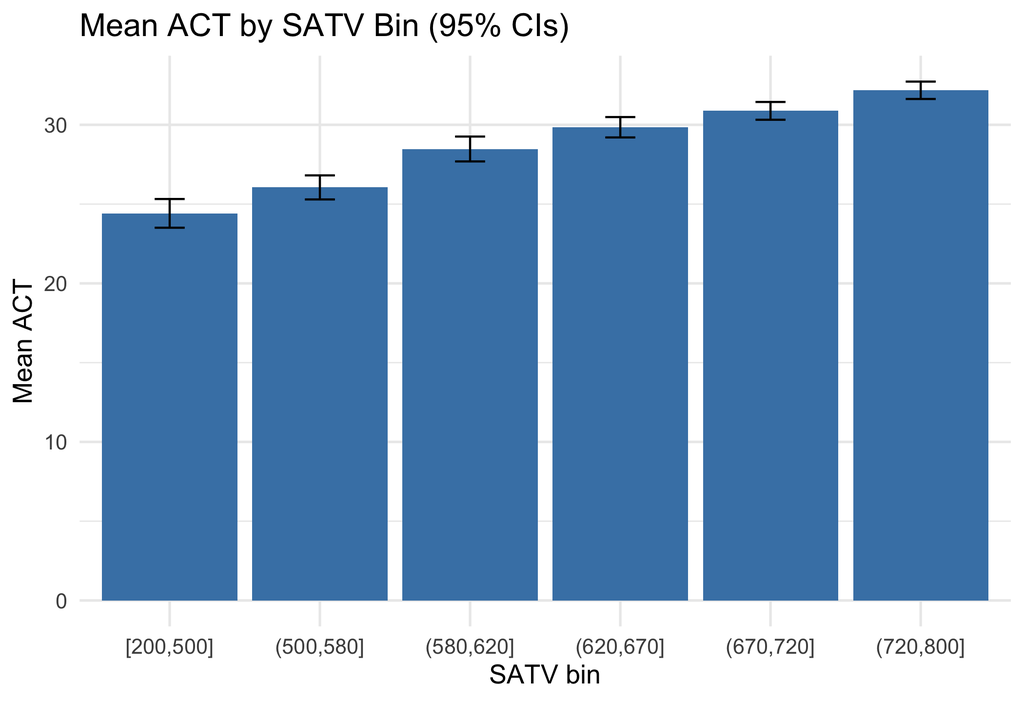

```r
sat2 <- sat %>%
  mutate(SATV_bin = cut_number(SATV, n = 6)) %>%
  group_by(SATV_bin) %>%
  summarise(
    mean_ACT = mean(ACT, na.rm = TRUE),
    sd_ACT   = sd(ACT, na.rm = TRUE),
    n        = n(),
    se       = sd_ACT/sqrt(n),
    lower    = mean_ACT - 1.96*se,
    upper    = mean_ACT + 1.96*se,
    .groups = "drop"
  )

ggplot(sat2, aes(SATV_bin, mean_ACT)) +
  geom_col(fill = "steelblue") +
  geom_errorbar(aes(ymin = lower, ymax = upper), width = .2) +
  labs(title = "Mean ACT by SATV Bin (95% CIs)", x = "SATV bin", y = "Mean ACT") +
  theme_minimal(base_size = 13)
```

## 0.9 8) MSQ (Mood Survey): Positive vs Negative Affect

**Data:** `psych::msq` (mood adjectives by person)  
**Goal:** Create two composite scales (e.g., **Positive Affect** and **Negative Affect**) by averaging chosen adjectives (document your choices). Compare the distributions and the **relationship** between the two scales.

```r
data(msq)

# TODO: choose subsets of mood adjectives to define PA and NA, then:
# msq2 <- msq %>%
#   mutate(PA = rowMeans(select(., <positive item cols>), na.rm=TRUE),
#          NA = rowMeans(select(., <negative item cols>), na.rm=TRUE)) %>%
#   filter(!is.na(PA), !is.na(NA))
#
# TODO: visualize distributions (hist/density/violin) and PA vs NA (scatter or 2D density)
```

## 0.10 9) MSQ Reduced (`msqR`): Profile by Group

**Data:** `psych::msqR` (a reduced mood item set)  
**Goal:** Select any **4–6 mood items**, reshape to **long** (item,value), group by a binary split you define (e.g., median split on one item), and create a **profile plot** (mean ± SE across items).

```r
data(msqR)

# TODO: pick items, pivot longer, create a grouping variable (e.g., high vs low on 'active')
# Summarise mean and SE per item and group, then plot lines with points and error bars
```

## 0.11 10) Ability: Correlation Heatmap (from Covariance)

**Data:** `psych::ability.cov` (list with $cov and test names)  
**Goal:** Convert covariance to **correlation** with `cov2cor()`, then plot a **correlation heatmap**. Highlight clusters (e.g., spatial, verbal).

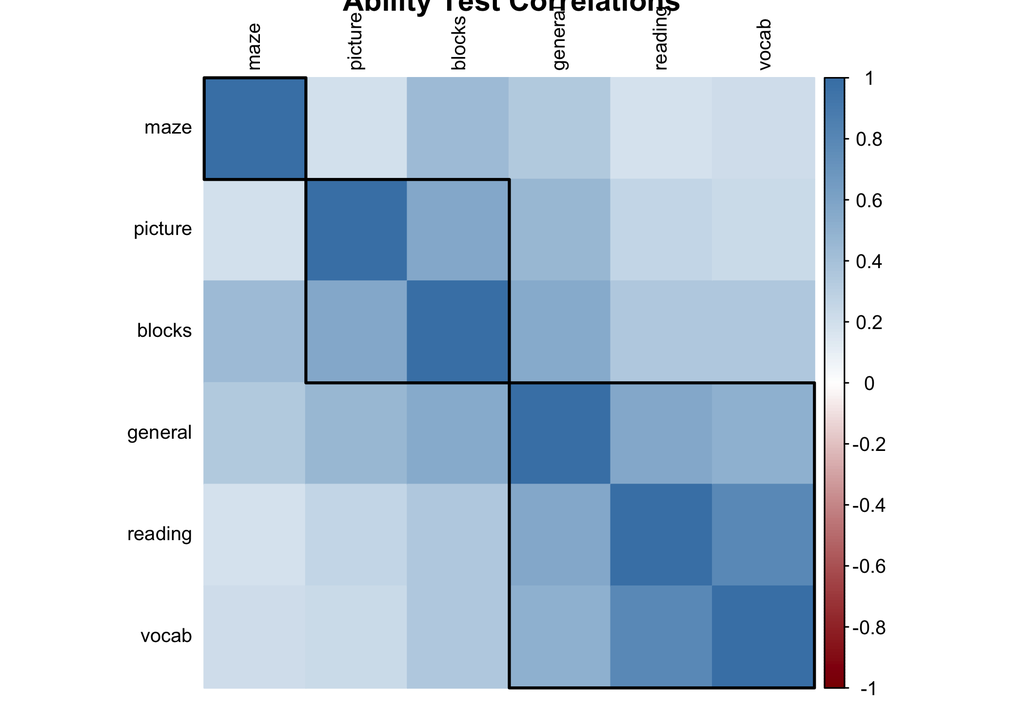

```r
data(ability.cov)

R_ability <- cov2cor(ability.cov$cov)

corrplot(R_ability, method = "color", order = "hclust", addrect = 3,
         tl.col = "black", tl.cex = .8,
         col = colorRampPalette(c("darkred","white","steelblue"))(200),
         title = "Ability Test Correlations")
```

## 0.12 11) Harman74: Correlogram with Numbers

**Data:** `psych::Harman74.cor` (correlation matrix + N)  
**Goal:** Plot a **mixed correlogram**: symbols/colors on one triangle and numbers on the other.

[figure not shown]

```r
data(Harman74.cor)

R_harman <- Harman74.cor$cov  # actually a correlation matrix
# Upper triangle: circles; Lower: numbers
corrplot(R_harman, method = "circle", type = "upper", order = "hclust",
         tl.col = "black", tl.cex = .6)
corrplot(R_harman, method = "number", type = "lower", add = TRUE, diag = FALSE, number.cex = .5)
```

## 0.13 12) BFI: Trait Profiles by Education

**Goal:** Compute mean **E, A, C, N, O** per participant, pivot **long** to trait/value.  
Create a **profile plot** (trait on x, mean value on y) by **education** (facet or color). Add CIs.

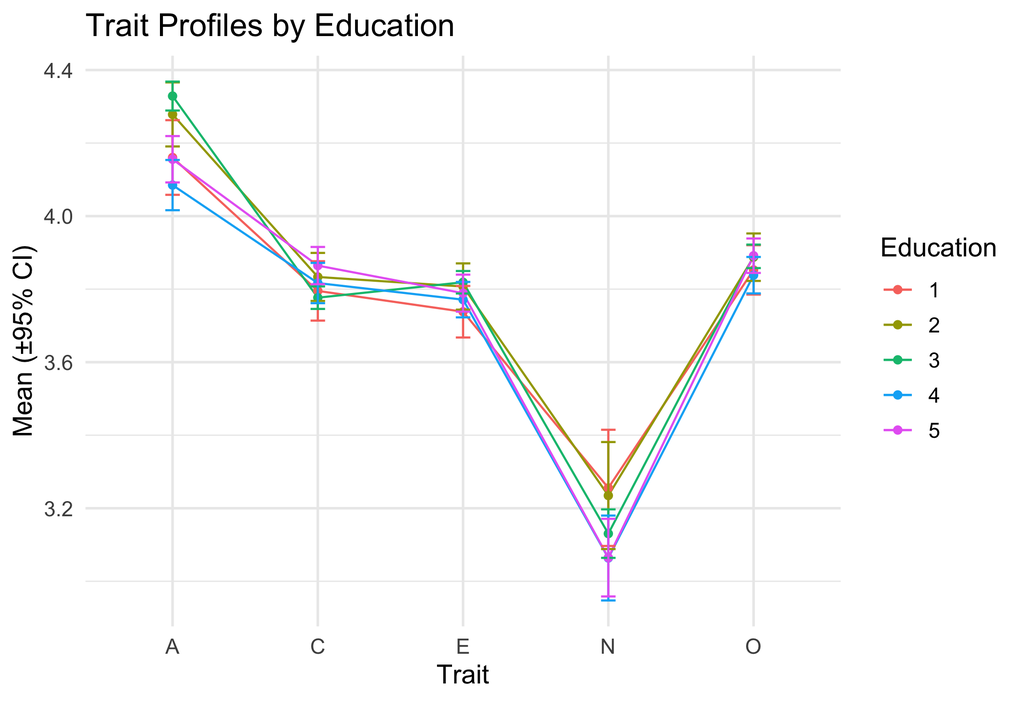

```r
bfi_traits <- bfi %>%
  mutate(
    E = rowMeans(select(., E1:E5), na.rm = TRUE),
    A = rowMeans(select(., A1:A5), na.rm = TRUE),
    C = rowMeans(select(., C1:C5), na.rm = TRUE),
    N = rowMeans(select(., N1:N5), na.rm = TRUE),
    O = rowMeans(select(., O1:O5), na.rm = TRUE)
  ) %>%
  select(E,A,C,N,O, education) %>%
  filter(!is.na(education)) %>%
  pivot_longer(E:O, names_to = "Trait", values_to = "Score")

bfi_prof <- bfi_traits %>%
  group_by(education, Trait) %>%
  summarise(
    mean = mean(Score, na.rm = TRUE),
    sd = sd(Score, na.rm = TRUE),
    n = n(),
    se = sd/sqrt(n),
    lower = mean - 1.96*se,
    upper = mean + 1.96*se,
    .groups = "drop"
  )

ggplot(bfi_prof, aes(Trait, mean, group = education, color = factor(education))) +
  geom_line() + geom_point() +
  geom_errorbar(aes(ymin = lower, ymax = upper), width = .1) +
  labs(title = "Trait Profiles by Education", x = "Trait", y = "Mean (±95% CI)", color = "Education") +
  theme_minimal(base_size = 13)
```

## 0.14 13) BFI: Age Trends in Traits

**Goal:** For any **two traits** of your choice, examine how scores change with **age**.  
Choose either a **scatter + smooth** (individuals) or **bin age** and plot **mean ± SE** by bin.

```r
bfi_age <- bfi %>%
  mutate(
    E = rowMeans(select(., E1:E5), na.rm = TRUE),
    C = rowMeans(select(., C1:C5), na.rm = TRUE)
  ) %>%
  filter(!is.na(age), !is.na(E), !is.na(C))

# TODO: pick trait(s) vs age and visualize trends; annotate any patterns
```

## 0.15 14) SAT & ACT: Choose the View

**Goal:** Decide on an **appropriate plot** to communicate how **SATQ** relates to **ACT**, conditioned on **SATV** (e.g., faceting SATV bins or using color gradients). Justify your choice.

```r
# sat from earlier (p6)
# TODO: facet or color by SATV bins/gradients; show SATQ vs ACT; add explanation
```

## 0.16 15) MSQ or BFI: Outlier Hunt

**Goal:** Choose either `msq` or `bfi`.  
Define a composite score (e.g., PA from `msq`, or a trait from `bfi`) and use **a plot suitable for spotting outliers** (e.g., boxplot with points, z-score scatter, or Tukey fences). Briefly discuss the outliers.

```r
# TODO: compute composite, standardize if helpful, and create outlier-focused visualization
```

# 1 Part 2 — Open-Ended Problems (Tidy + Choose the Plot)

For each, you must **tidy the data** and **choose** a plot that best communicates the result. Add a brief justification.

## 1.1 16) BFI: Trait Interactions by Gender

**Goal:** Investigate whether the relationship between two traits (you choose) **differs by gender**.  
Hints: compute trait means, then either **faceted 2D density**, **grouped scatter + smooth**, or **interaction line plot** after binning.

```r
# TODO: compute two trait means, tidy gender, choose and implement visualization
```

## 1.2 17) MSQ: Mood Structure

**Goal:** Use `msq` to **define and justify** two mood composites (e.g., Activation vs. Valence).  
Visualize the **joint distribution** and identify clusters or gradients.

```r
# TODO: select items, compute composites, visualize joint shape (2D density/hexbin/scatter)
```

## 1.3 18) SAT & ACT: Who Outperforms?

**Goal:** Identify students whose **ACT** is notably higher/lower than what their **SATV/SATQ** would predict.  
Approaches: regression residuals or stratified comparisons; plot residuals vs predictors and flag extremes.

```r
# TODO: fit model(s), compute residuals, visualize residuals and flag outliers
```

## 1.4 19) Ability: Neighborhood Map of Tests

**Goal:** Convert `ability.cov$cov` to correlations and create a **network-style** visualization (e.g., **pairs plot**, **MDS map**, or **clustered heatmap**) that communicates **which tests hang together**. Explain your choice.

```r
# TODO: cov2cor, then choose visualization; if MDS: cmdscale on (1 - R)
```

## 1.5 20) Harman74: Factor-Like Insight via Visualization

**Goal:** Without running factor analysis, produce a visualization (heatmap/cluster/correlogram) that **suggests** how many latent dimensions might be present. Briefly argue for your number based on the picture.

```r
# TODO: visual approach that reveals block structure; add short justification
```

## 1.6 21) “Tell a Data Story” (psych only)

Pick **one dataset** from `psych` (`bfi`, `msq`, `msqR`, `sat.act`, `ability.cov`, `Harman74.cor`).  
Ask a meaningful question, **tidy** the data, and produce **1–2 plots** that answer it.  
Write a short caption (3–5 sentences) explaining your findings and why the charts fit the question.

```r
# TODO: choose data, tidy, visualize, and caption
```

## 1.7 Rubric (10 pts each)

| Criterion | Description |
| --- | --- |
| **Data Tidiness** | Data reshaped/cleaned appropriately for plotting |
| **Visualization Choice** | Appropriate for variables and question; justified |
| **Aesthetics & Clarity** | Labels, guides, and themes aid understanding |
| **Interpretation** | Clear, concise takeaway or insight |
| **Reproducibility** | Code runs and yields intended outputs |